# Assignment 2 Task 2

Grace Bianchi

2023-02-16

Description: This code wrangles lizard data collected from the Jornado Basin LTER site and non-linear least squares is used to estimate the parameters of a length to weight model for lizard populations in New Mexico.

**Citation:** Lightfoot, D. and W.G. Whitford. 2020. Lizard pitfall trap data from 11 NPP study locations at the Jornada Basin LTER site, 1989-2006 ver 37. Environmental Data Initiative. https://doi.org/10.6073/pasta/4a6e258fb49c31e222ecbbcfd128967f

```r
knitr::opts_chunk$set(echo = TRUE, message = FALSE, warning = FALSE)

library(tidyverse)
library(here)
library(janitor)
library(kableExtra)
library(Metrics)
library(broom)
```

```r
lizard_data <- read_csv(here("task2", "lizards.csv")) %>%
  clean_names()
```

### Model Fitting

The following equation is used to fit snout length to lizard weight, in which weight is given by W, snout to vent length by SVL, and a and b are the parameters that need to be fitted.

$$W = a(SVL)^b$$

```r
svl_model <-function(sv_length, a, b){
  w = a*(sv_length^b)
  return(w)
}
```

The model is exponential, so data is log transformed to get approximations of the parameters from the regression coefficients.

### Model Guessing and Coefficients

```r
my_guess_model <- lm(log(lizard_data$weight) ~ log(lizard_data$sv_length), data = lizard_data)

# coefficients(my_guess_model)

# raise coefficient to cancel out log function
a <- exp(my_guess_model$coefficients[1])
b <- my_guess_model$coefficients[2]
```

### Non-linear least squares

```r
lizard_nls <-nls(weight~svl_model(sv_length, a, b),
              data = lizard_data,
              start = list(a = a, b = b))
```

```r
nls_tidy <- tidy(lizard_nls)

nls_tidy %>% kable(caption = "Table 1. NLS Parameter Estimates",
  col.names = c("Parameter", "Estimate", "Standard Error", "statistic", "P-value")) %>%
  kable_classic() %>%
  kable_styling(full_width = FALSE)
```

Table 1. NLS Parameter Estimates

| Parameter | Estimate | Standard Error | statistic | P-value |
| --- | --- | --- | --- | --- |
| a | 0.0001073 | 0.0000091 | 11.77374 | 0 |
| b | 2.7209865 | 0.0196796 | 138.26425 | 0 |

### Model Predictions

```r
lizards_pred <- lizard_data %>%
  mutate(pred_w = predict(lizard_nls, newdata=.))

lizards_rmse <- rmse(lizards_pred$weight, lizards_pred$pred_w)
```

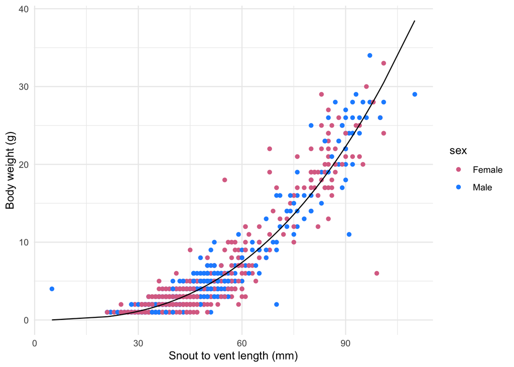

```r
ggplot(data = lizards_pred, aes(x = sv_length, y = weight)) +
  geom_point(aes(color = sex)) +
  theme_minimal() +
  scale_color_manual(values = c("palevioletred", "dodgerblue"),
                     labels = c("Female", "Male")) +
  geom_line(aes(x = sv_length, y = pred_w)) +
  labs(x = "Snout to vent length (mm)",
       y = "Body weight (g)")
```

**Figure 1.** Fitted Snout to Vent Length Model of lizards observed in New Mexico, separated by sex, with an rmse of 1.56.